# HW 2: From correlation to linear mixed-effect models. Assignment sheet

## Задание 1

### 1.0

```r
shva <- read.csv('https://raw.githubusercontent.com/agricolamz/2018-MAG_R_course/master/data/duryagin_ReductionRussian.txt', sep='\t')
```

### 1.1

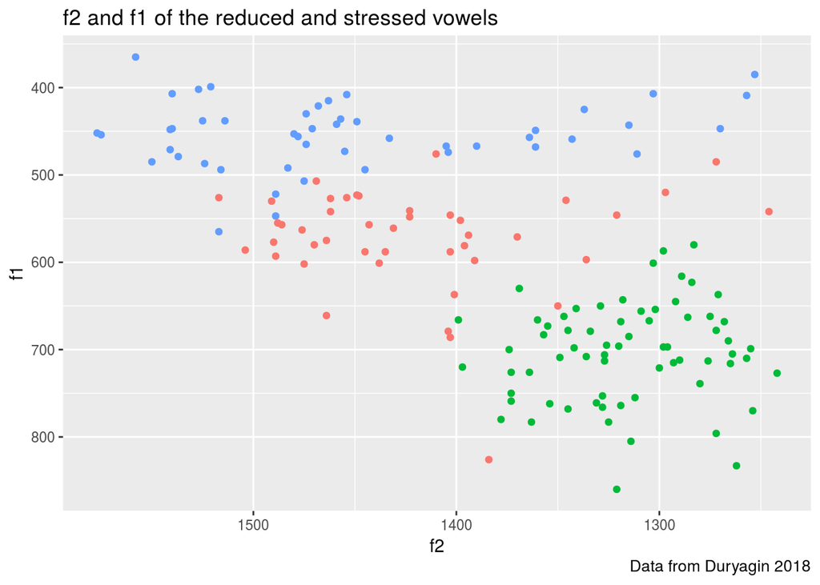

```r
ggplot(data=shva, aes(f2, f1)) + geom_point(aes(colour=factor(shva$vowel)), show.legend = F) + scale_y_reverse() + scale_x_reverse() + labs(title='f2 and f1 of the reduced and stressed vowels', caption="Data from Duryagin 2018")
```

### 1.2 Plot the boxplots of f1 and f2 for each vowel using ggplot().

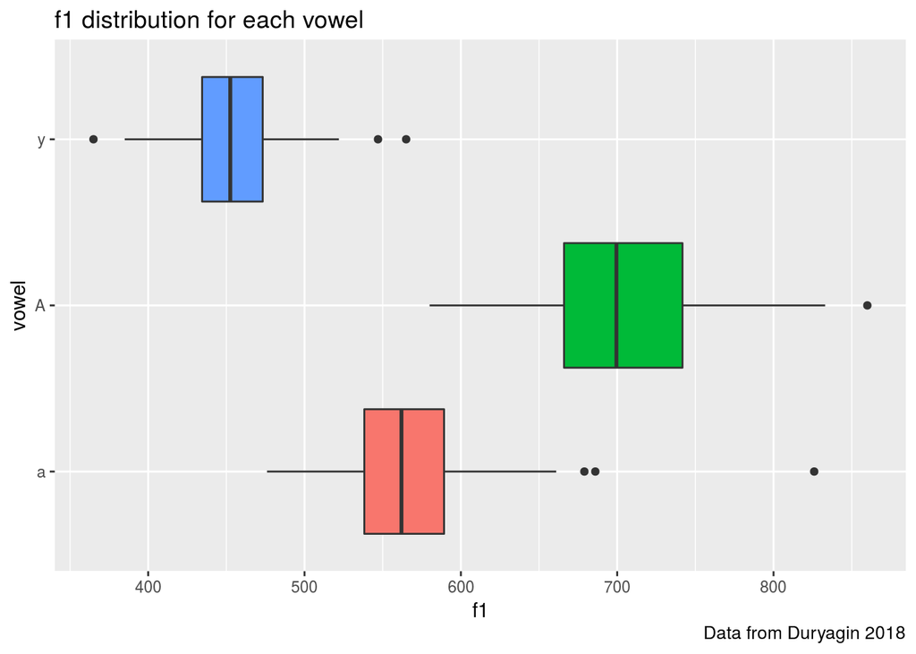

```r
ggplot(data=shva, aes(vowel, f1)) + geom_boxplot(aes(fill=factor(shva$vowel)), show.legend = F) + coord_flip() + labs(title='f1 distribution for each vowel', caption="Data from Duryagin 2018")
```

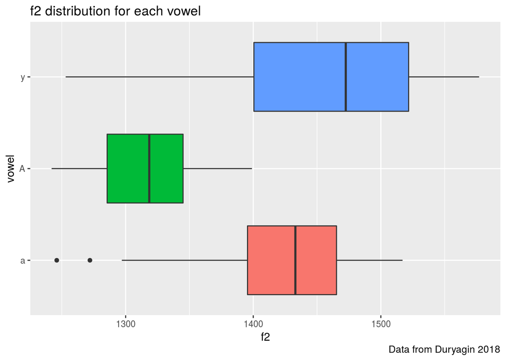

```r
ggplot(data=shva, aes(vowel, f2)) + geom_boxplot(aes(fill=factor(shva$vowel)), show.legend = F) + coord_flip() + labs(title='f2 distribution for each vowel', caption="Data from Duryagin 2018")
```

### 1.3 Which f1 can be considered outliers in a vowel?

3 точки из y, одна точка из A, три точки из а

### 1.4 Calculate Pearson’s correlation of f1 and f2 (all data)

```r
cor(shva$f1, shva$f2, method='pearson')
```

```
## [1] -0.5797475
```

### 1.5 Calculate Pearson’s correlation of f1 and f2 for each vowel

```r
a <- shva[shva$vowel=='a',]
y <- shva[shva$vowel=='y',]
A <- shva[shva$vowel=='A',]
print(cor(a$f1, a$f2))
```

```
## [1] -0.01126545
```

```r
print(cor(y$f1, y$f2))
```

```
## [1] 0.181871
```

```r
print(cor(A$f1, A$f2))
```

```
## [1] 0.1032741
```

## 1.6 Use the linear regression model to predict f2 by f1.

```r
m <- lm(f2~f1, data=shva)
```

#### 1.6.1 Provide the result regression formula

```r
coefficients(m)
```

```
##  (Intercept)           f1
## 1639.7021488   -0.4287498
```

> 1639.7021488 - 0.4287498 f1

#### 1.6.2 Provide the adjusted R2

```r
summary(m)
```

```
##
## Call:
## lm(formula = f2 ~ f1, data = shva)
##
## Residuals:
##      Min       1Q   Median       3Q      Max
## -221.633  -46.447    6.354   54.352  131.093
##
## Coefficients:
##               Estimate Std. Error t value Pr(>|t|)
## (Intercept) 1639.70215   28.97365  56.593  < 2e-16 ***
## f1            -0.42875    0.04794  -8.944 9.53e-16 ***
## ---
## Signif. codes:  0 '***' 0.001 '**' 0.01 '*' 0.05 '.' 0.1 ' ' 1
##
## Residual standard error: 71.51 on 158 degrees of freedom
## Multiple R-squared:  0.3361, Adjusted R-squared:  0.3319
## F-statistic: 79.99 on 1 and 158 DF,  p-value: 9.533e-16
```

#### 1.6.3 Add the regression line in scatterplot 1.1

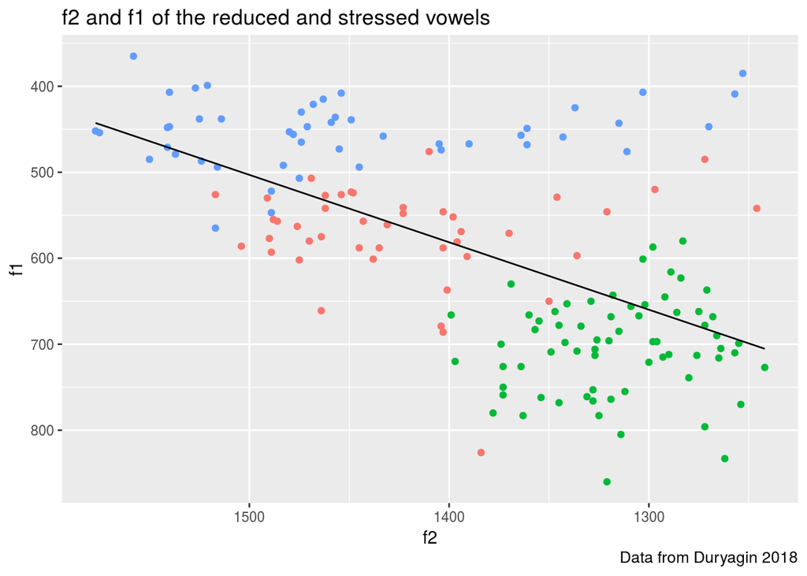

```r
for_the_picture <- lm(f1~f2, data=shva)
ggplot(data=shva, aes(f2, f1)) +
  geom_point(aes(colour=factor(shva$vowel)), show.legend = F) +
  geom_line(aes(f2, predict(for_the_picture))) +
  scale_y_reverse() +
  scale_x_reverse() +
  labs(title='f2 and f1 of the reduced and stressed vowels', caption="Data from Duryagin 2018")
```

### 1.7 Use the mixed-efects model to predict f2 by f1 using vowel intercept as a random effect

```r
m2 <- lmer(f2~f1+(1|vowel), data=shva)
```

#### 1.7.1 Provide the fixed effects formula

```r
fixef(m2)
```

```
##  (Intercept)           f1
## 1.356317e+03 6.889843e-02
```

#### 1.7.2 Provide the variance for intercept argument for vowel random effects

```r
summary(m2)
```

```
## Linear mixed model fit by REML ['lmerMod']
## Formula: f2 ~ f1 + (1 | vowel)
##    Data: shva
##
## REML criterion at convergence: 1785
##
## Scaled residuals:
##     Min      1Q  Median      3Q     Max
## -3.0589 -0.4377  0.1135  0.6653  2.0036
##
## Random effects:
##  Groups   Name        Variance Std.Dev.
##  vowel    (Intercept) 6374     79.84
##  Residual             3980     63.09
## Number of obs: 160, groups:  vowel, 3
##
## Fixed effects:
##              Estimate Std. Error t value
## (Intercept) 1.356e+03  7.101e+01  19.100
## f1          6.890e-02  9.321e-02   0.739
##
## Correlation of Fixed Effects:
##    (Intr)
## f1 -0.757
```

Variance: > 6374

## Задание 2

### 2.0 Read the data from file to the variable elp.

```r
elp <- read.csv('https://raw.githubusercontent.com/agricolamz/2018-MAG_R_course/master/data/ELP.csv')
```

### 2.1 Which two variables have the highest Pearson’s correlaton value.

```r
cor(elp$SUBTLWF, elp$Length, method='pearson')
```

```
## [1] -0.125193
```

```r
cor(elp$Mean_RT, elp$SUBTLWF, method='pearson')
```

```
## [1] -0.1457099
```

```r
cor(elp$Mean_RT, elp$Length, method='pearson')
```

```
## [1] 0.5276826
```

Ответ: `Mean_RT` ~ `Length`.

## Задание 3

### 3.0

```r
data <- read.csv('https://raw.githubusercontent.com/agricolamz/2018-MAG_R_course/master/data/dutch_causatives.csv', sep = ',')
```

### 3.1

Критерий χ2 плохо использовать, если хотя бы в одной из клеток ожидаемое значение меньше 5

```r
table <- table(data$Aux, data$CeSynt)
chisq.test(table)
```

```
## Warning in chisq.test(table): Chi-squared approximation may be incorrect
```

```
##
##  Pearson's Chi-squared test
##
## data:  table
## X-squared = 71.663, df = 3, p-value = 1.88e-15
```

получаем Warning: In chisq.test(table) : Chi-squared approximation may be incorrect

```r
chisq.test(table)$expected
```

```
## Warning in chisq.test(table): Chi-squared approximation may be incorrect
```

```
##
##         Clause   Impl     NP    PP
##   doen    3.74  22.78  45.56 12.92
##   laten  18.26 111.22 222.44 63.08
```

Понятно почему: в оюной из клеток значение 3.74. Если попробовать то же самое с остальными – всё хорошо. Следовательно, ответ – `Aux` ~ `CeSynt`.

```r
fisher.test(table)
```

```
##
##  Fisher's Exact Test for Count Data
##
## data:  table
## p-value < 2.2e-16
## alternative hypothesis: two.sided
```

p-value < 2.2e-16. Следовательно, значима.

### 3.2 Test the hypothesis that Aux and EPTrans are not independent with the help of Pearson’s Chi-squared Test.

```r
table <- table(data$Aux, data$EPTrans)
chisq.test(table)
```

```
##
##  Pearson's Chi-squared test with Yates' continuity correction
##
## data:  table
## X-squared = 14.307, df = 1, p-value = 0.0001553
```

p-value = 0.0001553 -> yes, they are dependent.

### 3.3 Provide expected values for Pearson’s Chi-squared Test of Aux and EPTrans variables.

```r
chisq.test(table)$expected
```

```
##
##           Intr     Tr
##   doen   40.63  44.37
##   laten 198.37 216.63
```

### 3.4 Calculate the odds ratio

```r
fisher.test(table)$estimate
```

```
## odds ratio
##   2.601174
```

odds ratio = 2.601174

### 3.5 Calculate effect size for this test using Cramer’s V (phi).

```r
library(questionr)
cramer.v(table)
```

```
## [1] 0.1744882
```

### 3.6 Report the results of independence

We have found a significant association between variables `Aux` and `EPTrans` (p < 0.001). Effect size is small (Cramer’s V = 0.1744882).

### 3.7 Visualize the distribution using mosaic plot.

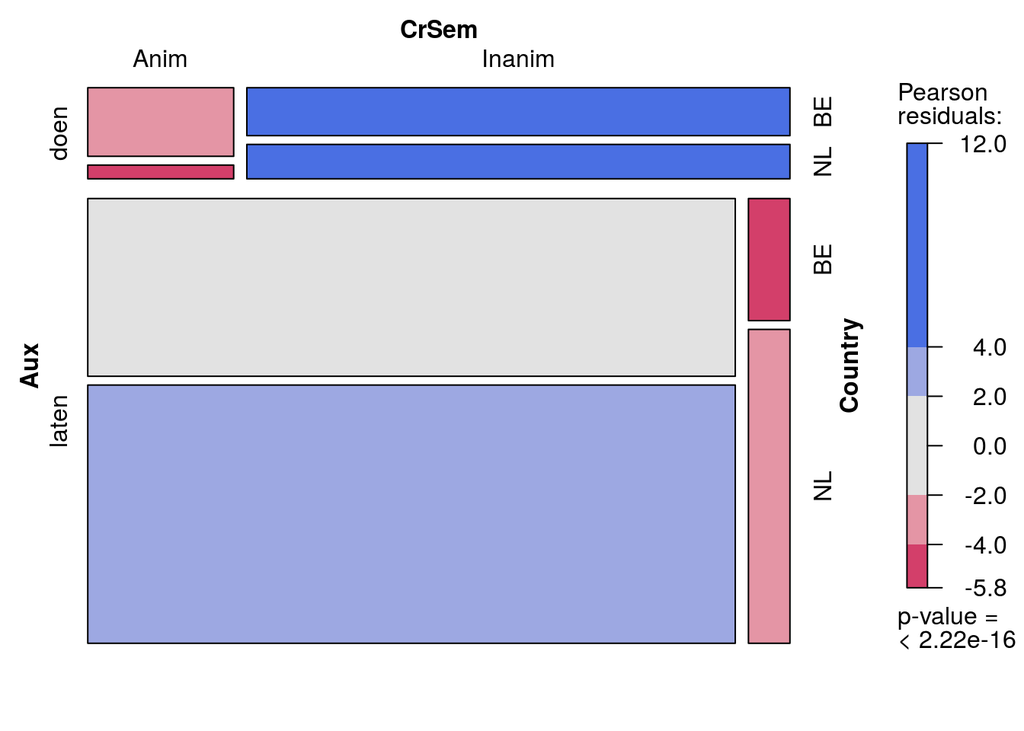

```r
library(vcd)
mosaic(~ Aux + CrSem + Country, data=data, shade=TRUE, legend=TRUE)
```

### 3.8

https://xkcd.com/882/